# Simulation

Tianyou Wang

2022-11-25

Note: `set.seed(1)` setting will let R give you the same numbers for `rnorm` for every single time you knit your file.

## Simulation: Mean and SD for one n

In *writing functions* we wrote a short function to simulate data from a normal distribution, and return estimates of the mean and standard deviation.

```r
sim_mean_sd = function(n, mu = 2, sigma = 3) {

  sim_data =
    tibble(
      x = rnorm(n, mean = mu, sd = sigma),
  )

  sim_data %>%
    summarize(
      mu_hat = mean(x),
      sigma_hat = sd(x)
    )
}
```

```r
sim_mean_sd(30)
```

```
## # A tibble: 1 × 2
##   mu_hat sigma_hat
##    <dbl>     <dbl>
## 1   2.25      2.77
```

Let’s run `sim_mean_sd()` 100 times to see the effect of randomness in xi on estimates μ̂ ,σ̂.There are multiple ways.

### **#1 `for` loop**

Start with a `for` loop.

```r
output = vector("list", 100)

for (i in 1:100) {
  output[[i]] = sim_mean_sd(30)
}

sim_results = bind_rows(output)
```

### **#2 loop function `rerun`**

Let’s use a loop function, `rerun`. This will give us the same thing as the chunk above. Note: `rerun(number of times, expressions to re-run)`

```r
sim_results =
rerun(100, sim_mean_sd(n = 30)) %>%
  bind_rows()
```

### **#3 `expand_grid(., iter = )`**

The same thing can also be done by using `expand_grid()`

```r
?expand_grid
```

```r
sim_results_df =
  expand_grid(
    sample_size = 30,
    iter = 1:100
  ) %>%
  mutate(
    estimate_df = map(sample_size, sim_mean_sd)
  ) %>%
  unnest(estimate_df)
```

### **plots and summaries**

Let’s make some quick plots and compute some summaries for our simulation results.

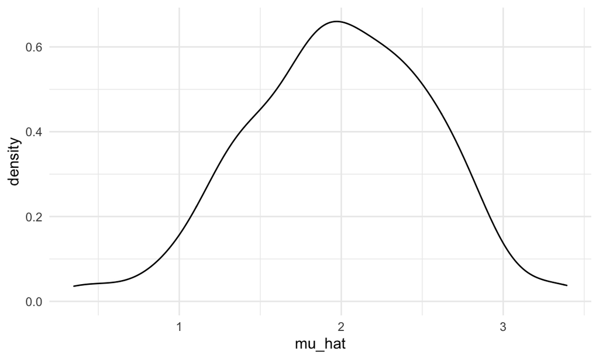

```r
sim_results %>%
  ggplot(aes(x = mu_hat)) +
  geom_density()
```

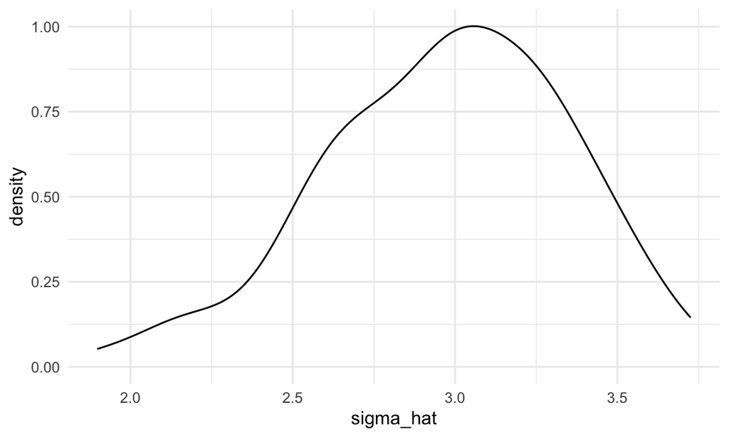

```r
sim_results %>%
  ggplot(aes(x = sigma_hat)) +
  geom_density()
```

```r
sim_results %>%
  summarize(
    avg_samp_mean = mean(mu_hat),
    sd_samp_mean = sd(mu_hat)
  )
```

```
## # A tibble: 1 × 2
##   avg_samp_mean sd_samp_mean
##           <dbl>        <dbl>
## 1          1.99        0.567
```

```r
sim_results %>%
  pivot_longer(
    mu_hat:sigma_hat,
    names_to = "parameter",
    values_to = "estimate") %>%
  group_by(parameter) %>%
  summarize(
    emp_mean = mean(estimate),
    emp_sd = sd(estimate)) %>%
  knitr::kable(digits = 3)
```

| parameter | emp_mean | emp_sd |
| --- | --- | --- |
| mu_hat | 1.985 | 0.567 |
| sigma_hat | 2.971 | 0.375 |

## Simulation: Mean for several n’s

Sample size makes a huge difference on the variance of estimates in SLR (and pretty much every statistical method). Let’s try to clarify that effect through simulating at a few sample sizes. Similarily, we will look into few ways.

### **#1 `for` loop**

```r
n_list = list(
  "n = 30" = 30,
  "n = 60" = 60,
  "n = 120" = 120,
  "n = 240" = 240
)

output = vector("list", length = 4)

output[[1]] = rerun(100, sim_mean_sd(n = n_list[[1]])) %>%
  bind_rows()

output[[2]] = rerun(100, sim_mean_sd(n = n_list[[2]])) %>%
  bind_rows()
```

To avoid using `output[[1]] = rerun(100, sim_mean_sd(n = n_list[[1]]))` multiple times, we gonna write a `for` loop.

```r
for (i in 1:4) {
  output[[i]] = rerun(100, sim_mean_sd(n = n_list[[i]])) %>%
  bind_rows()
}
```

### **#2 loop function `rerun` in `map`**

The above two chunks can also be down by this following code. We want to track everything we have into one data frame.

```r
sim_results =
tibble(
  sample_size = c(30, 60, 120, 240)
) %>%
  mutate(
    output_lists = map(.x = sample_size, ~ rerun(1000, sim_mean_sd(.x))),
    estimate_df = map(output_lists, bind_rows)
  ) %>%
  select(-output_lists) %>%
  unnest(estimate_df)
```

### **#3 `expand_grid(sample_size = , iter = )`**

We set up a tibble with iterations and the sample sizes we want to investigate using `expand_grid`.

```r
sim_results_df =
  expand_grid(
    sample_size = c(30, 60, 120, 240),
    iter = 1:1000
  ) %>%
  mutate(
    estimate_df = map(sample_size, sim_mean_sd)
  ) %>%
  unnest(estimate_df)
```

### **plots and summaries**

Violin graph: density distribution for the 1000 mu_hat’s among each sample size groups.

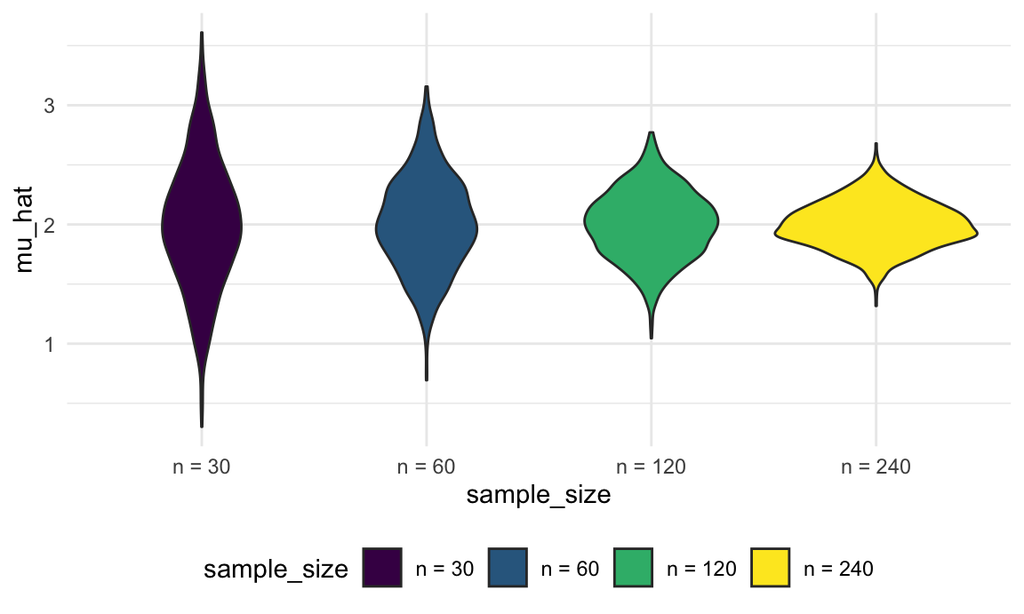

```r
sim_results %>%
  mutate(
    sample_size = str_c("n = ", sample_size),
    sample_size = fct_inorder(sample_size)) %>%
  ggplot(aes(x = sample_size, y = mu_hat, fill = sample_size)) +
  geom_violin()
```

Let’s look at the emprical mean and variance of the mean estimators (mu_hats).

```r
sim_results %>%
  group_by(sample_size) %>%
  summarize(
    ave_samp_mean = mean(mu_hat),
    sd_samp_mean = sd(mu_hat)
  )
```

```
## # A tibble: 4 × 3
##   sample_size ave_samp_mean sd_samp_mean
##         <dbl>         <dbl>        <dbl>
## 1          30          2.00        0.528
## 2          60          2.01        0.393
## 3         120          2.00        0.282
## 4         240          2.00        0.196
```

Lastly I’ll look at the empirical mean and variance of both the mean estimator (mu_hats) and std estimator (sigma_hat).

```r
sim_results %>%
  pivot_longer(
    mu_hat:sigma_hat,
    names_to = "parameter",
    values_to = "estimate") %>%
  group_by(parameter, sample_size) %>%
  summarize(
    emp_mean = mean(estimate),
    emp_var = var(estimate)) %>%
  knitr::kable(digits = 3)
```

| parameter | sample_size | emp_mean | emp_var |
| --- | --- | --- | --- |
| mu_hat | 30 | 2.001 | 0.279 |
| mu_hat | 60 | 2.006 | 0.154 |
| mu_hat | 120 | 2.001 | 0.079 |
| mu_hat | 240 | 1.999 | 0.038 |
| sigma_hat | 30 | 2.983 | 0.151 |
| sigma_hat | 60 | 3.001 | 0.077 |
| sigma_hat | 120 | 2.984 | 0.038 |
| sigma_hat | 240 | 2.994 | 0.019 |

## Varying two simulation parameters

`map2()` example:

```r
sim_results_df =
  expand_grid(
    sample_size = c(30, 60, 120, 240),
    true_sd = c(6, 3),
    iter = 1:1000
  ) %>%
  mutate(
    estimate_df =
      map2(.x = sample_size, .y = true_sd, ~ sim_mean_sd(n = .x, sigma = .y))
  ) %>%
  unnest(estimate_df)
```

Violin graph.

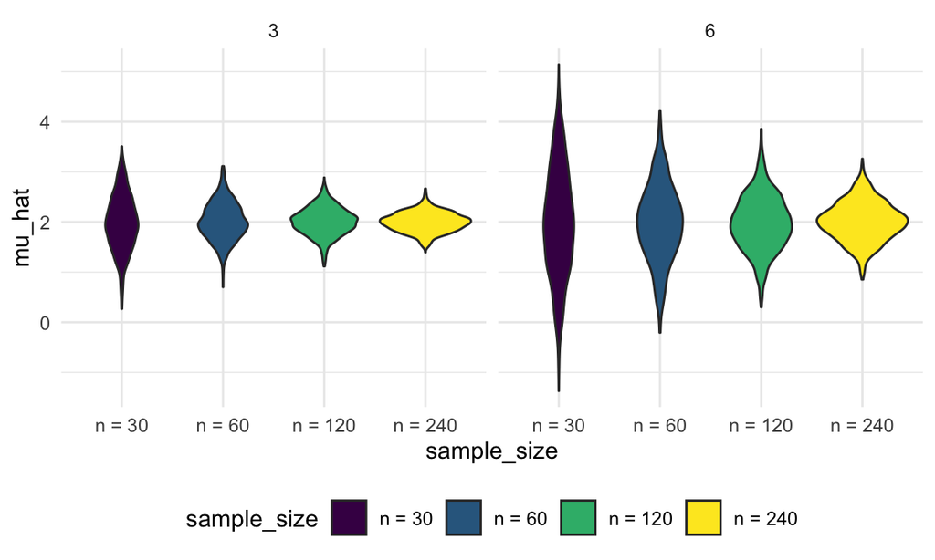

```r
sim_results_df %>%
  mutate(
    sample_size = str_c("n = ", sample_size),
    sample_size = fct_inorder(sample_size)) %>%
  ggplot(aes(x = sample_size, y = mu_hat, fill = sample_size)) +
  geom_violin() +
  facet_grid(. ~ true_sd)
```